# Homework1

Zihan Zhang;Xinjian Zhou;Thomas Martin

2017/9/13

## Introduction

This assignment introduces our group and shows that we understand how to use github and r markdown. We start with a video introducing our members and then each have a summary of our schedule and interests. Last, we have a lot of rmarkdown code to show that we understand how to use r markdown.

[video not shown]

## Group Members

#### Zihan Zhang

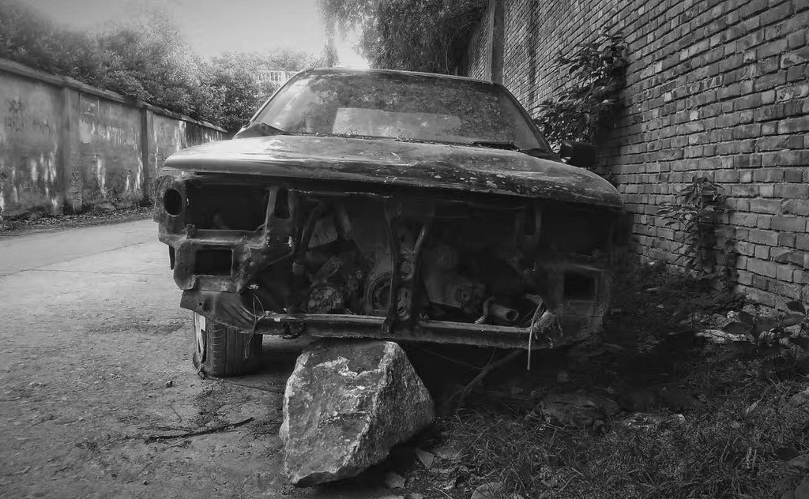

A photo I took with my phone

I love photography, video games, and reading. One interesting fact about me is that this is my first semester at PSU since I’m a transfer student.

My favorite quote is

> “Sometimes things become possible if we want them bad enough”-T.S.Eliot

| Courses | Time |
| --- | --- |
| STAT 461 | 8:00-8:50 MWF |
| Math 230 | 9:05-9:55 MWThF |
| STAT 414 | 1:25-2:15 MWF |
| ACCT 211 | 8:00-8:50 TTh |
| STAT 297 | 12:05-1:20 TTh |
| JST012 | 3:05-4:20 TTh |

#### Thomas Martin

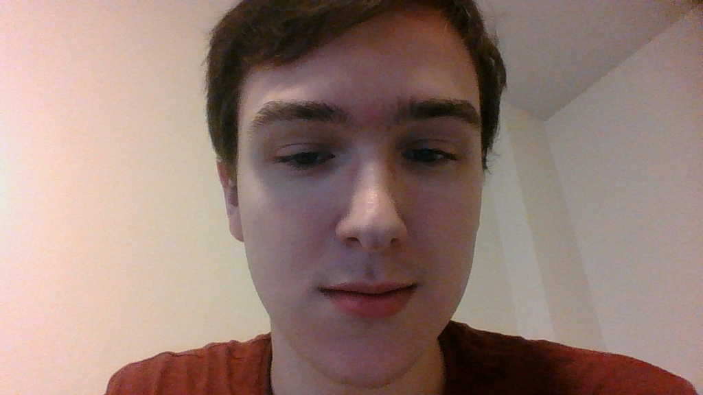

Here is a picture of me

My favorite hobbies are swimming and playing video games. An interesting fact about me is that I was born on Christmas.

My favorite quote is:

> “The only source of knowledge is experience.”- Albert Einstein

| Courses | Time |
| --- | --- |
| ASTRO 1 | WEB |
| STAT 461 | 8:00-8:50 MWF |
| ENGL 202B | 9:05-10:20 TTh |
| STAT 414 | 11:15-12:05 MWF |
| GLIS 102 | 3:05-4:30 TTh |
| STAT 297 | 12:05-1:20 TTh |

[figure not shown]

My photo was took at Alasks last year

Just as my other group members, I like video games! I also like to do rafting. I also like bedmintons.

Here is my favorite quote:

> “Great things in business are never done by one person. They’re done by a team of people.”- Steve Jobs

| Courses | Time |
| --- | --- |
| STAT 461 | 8:00-8:50 MWF |
| STAT 415 | 4:40-5:30 MWF |
| STAT 416 | 3:35-4:20 MWF |
| STAT 297 | 12:05-1:20 TTh |
| SC 220 | 6:05-7:30 M |
| IE 460 | 10:10-11:00 MWF |
| IE 470 LEC | 9:05-9:55 MW |
| IE 470 LAB | 3:35-5:25 T |
| IE 497 | 1:25-2:15 MWF |

## R Markdown Syntax

- Part 1

```r
a=120
```

```r
(c=a/3)
```

```
## [1] 40
```

```r
(c=a/3)
```

```
## [1] 40
```

- Part 2

```r
x=rnorm(100)
median(x)
```

```
## [1] 0.02574278
```

```r
mean(x)
```

```
## [1] 0.04068871
```

```r
sd(x)
```

```
## [1] 1.068749
```

Analysis of the random data: The results are normal since they are very close to 0,0,1.

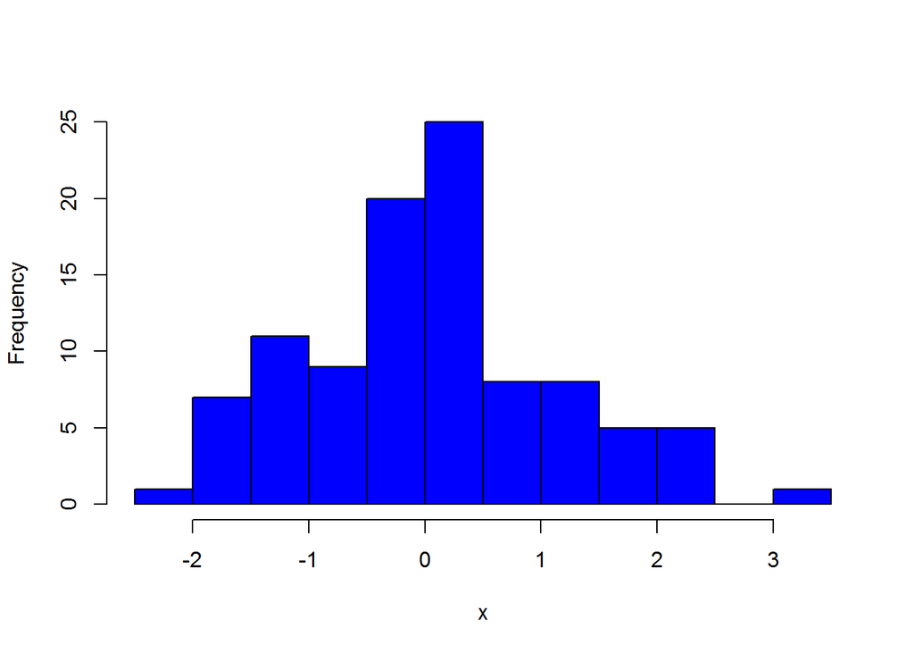

**Histogram:** 100 random virables from normal random distribution

```r
hist(x,main="", col = "blue")
```

- Part 3
- $$𝔼[var(v_{1}(\hat{\theta },n)|\hat{\theta})]=var(v_{1}(\theta _{0},0))+𝔼[\vartheta _{p}(D_{1}(\theta ^{*},n)(\hat{\theta }-\theta _{0}),...,D_{p}(\theta ^{*},n)(\theta -\theta _{0}))]$$
  $$=var(v_{1}(\theta _{0},n)+\vartheta (n^{-2}))$$
  $$A=[a_{ij}]_{ij=1,...,p}$$

“Vérité dans un temps, erreur dans un autre.???, Charles de Montesquieu

Warning!This is the end of the page

## Reference

- R Markdown From R Studio. (n.d.). Retrieved September 14, 2017, from http://rmarkdown.rstudio.com/lesson-3.html
- Matthew Beckman, Stéphane Guerrier, Justin Lee & Roberto Molinari. (2017, September 11). An Introduction to Statistical Programming Methods with R. Retrieved September 14, 2017, from https://smac-group.github.io/ds/rmarkdown.html#
- https://www.codecogs.com/latex/eqneditor.php